# Solar Panel Analysis

This data has been gathered at two solar power plants in India over a 34 day period. It has two pairs of files - each pair has one power generation dataset and one sensor readings dataset. The power generation datasets are gathered at the inverter level - each inverter has multiple lines of solar panels attached to it. The sensor data is gathered at a plant level - single array of sensors optimally placed at the plant.

### Provenance

**Sources**

*Power generation and sensor data gathered from two solar power plants*

**Collection methodology**

*Power generation and sensor data gathered at 15 minutes intervals over a 34 day period. Generation data collected at inverter level, while the sensor data is at the plant level.*

### Columns

**Plant 1&2 Generation data @Inverter level**

```
            DATE_TIME- Date and time for each observation.
                       Observations recorded at 15 minute intervals.

            PLANT_ID - this will be common for the entire file.

            SOURCE_KEY - Source key in this file stands for the inverter id.
                         changed to Inverter id)

            DC_POWER - Amount of DC power generated by the inverter (source_key)
                       in this 15 minute interval. Units - kW.

            AC_POWER - Amount of AC power generated by the inverter (source_key)
                       in this 15 minute interval. Units - kW.

            DAILY_YIELD - Daily yield is a cumulative sum of power generated
                          on that day, till that point in time.

            TOTAL_YIELD - This is the total yield for the inverter till that
                          point in time.
```

**Plant 1&2 Weather sensor data @Plant level**

```
            DATE_TIME- Date and time for each observation.
                       Observations recorded at 15 minute intervals.

            PLANT_ID - this will be common for the entire file.

            SOURCE_KEY - Stands for the sensor panel id. This will be
                         common for the entire file because there's
                         only one sensor panel for the plant.

            AMBIENT_TEMPERATURE - This is the ambient temperature at
                                  the plant.

            MODULE_TEMPERATURE - There's a module (solar panel) attached
                                 to the sensor panel. This is the
                                 temperature reading for that module.
```

```python
import pandas as pd
import matplotlib.pyplot as plt
import matplotlib as mlp
import seaborn as sns
import numpy as np
import stat as st
import datetime as dt
```

```python
gen_1 = pd.read_csv('Plant_1_Generation_Data.csv',delimiter=',')
gen_2 = pd.read_csv('Plant_2_Generation_Data.csv',delimiter=',')

s1 = pd.read_csv('Plant_1_Weather_Sensor_Data.csv',delimiter=',')
s2 = pd.read_csv('Plant_2_Weather_Sensor_Data.csv',delimiter=',')

gen_1.rename(columns={'SOURCE_KEY':'INVERTER_ID'},inplace =True)
gen_2.rename(columns={'SOURCE_KEY':'INVERTER_ID'},inplace =True)
```

# Functions

```python
def slice_df(columns,data=[gen_1,gen_2]):
    df1= data[0].copy()
    df2=data[1].copy()
    df1 = df1[columns]
    df2 = df2[columns]

    return (df1),(df2)
```

```python
def split_date(df,h=False,**kwargs):
    reset = kwargs.get('reset',False)

    if reset == True:
        df = df.reset_index()

    df['TIME'] = df["DATE_TIME"].dt.time
    df['DATE'] = df['DATE_TIME'].dt.date

    #convert to hour
    if h ==True:
        df['HOUR'] = df['DATE_TIME'].apply(lambda t : t.hour)

    return df
```

```python
def Generate_sd_mean(df,df2,column,rows=1,cols=2):
    #agg as list.
    #column as str
    results={}
    results[0]= df.groupby('TIME')[column].agg(['mean','std'])
    results[1] = df2.groupby('TIME')[column].agg(['mean','std'])
    fig,axes = plt.subplots(rows,cols,figsize=(13,6))

    ax={}
    for i in range(0,rows*cols):
        ax[i]= results[i]['mean'].plot(ax=axes[i])
        ax[i].fill_between(results[i].index,results[i]['mean']-results[i]['std'],results[i]['mean']+results[i]['std'],color='b',alpha=0.3)
```

```python
def groupby_inv_date(df,freq,fillna=False,agg_m = 'count',multi_index=True,**kwargs):

    col = kwargs.get('col','INVERTER_ID')
    if multi_index ==False:
        gb = df.groupby(pd.Grouper(freq=freq,key='DATE_TIME'))[col].agg([agg_m])
        gb_org = gb.unstack().transpose()
    else:
        gb = df.groupby(['INVERTER_ID',pd.Grouper(freq=freq,key='DATE_TIME')])[col].agg(agg_m)
        gb_org = gb.unstack().transpose()

    if fillna == True:
        gb_org_cleaned = gb_org.fillna(0)
        return gb_org_cleaned

    return gb_org
```

```python
def groupby_power(df1,df2=None,freq='15t',cols=['AC_POWER','DC_POWER'],agg_m='mean',multi_index=False,**kwargs):

    r = kwargs.get('reset_i',False)

    gb1 = df1.groupby(pd.Grouper(freq=freq,key='DATE_TIME'))[cols].agg(agg_m)
    if df2 is not None:
        gb2 = df2.groupby(pd.Grouper(freq=freq,key='DATE_TIME'))[cols].agg(agg_m)
    if r ==True:
        gb1 = gb1.reset_index()
        gb2 = gb2.reset_index()

    if df2 is not None:
        return gb1,gb2
    return gb1
```

# Understanding the data

## Generation data

```python
gen_1.info()
```

```
<class 'pandas.core.frame.DataFrame'>
RangeIndex: 68778 entries, 0 to 68777
Data columns (total 7 columns):
 #   Column       Non-Null Count  Dtype
---  ------       --------------  -----
 0   DATE_TIME    68778 non-null  object
 1   PLANT_ID     68778 non-null  int64
 2   INVERTER_ID  68778 non-null  object
 3   DC_POWER     68778 non-null  float64
 4   AC_POWER     68778 non-null  float64
 5   DAILY_YIELD  68778 non-null  float64
 6   TOTAL_YIELD  68778 non-null  float64
dtypes: float64(4), int64(1), object(2)
memory usage: 3.7+ MB
```

```python
print('gen1 # of Inverters:',gen_1['INVERTER_ID'].nunique())
print('gen2 # of Inverters:',gen_2['INVERTER_ID'].nunique())
```

```
gen1 # of Inverters: 22
gen2 # of Inverters: 22
```

```python
gen_1[['DATE_TIME','PLANT_ID','INVERTER_ID','DC_POWER']].head(23)
```

|  | DATE_TIME | PLANT_ID | INVERTER_ID | DC_POWER |
| --- | --- | --- | --- | --- |
| 0 | 15-05-2020 00:00 | 4135001 | 1BY6WEcLGh8j5v7 | 0.0 |
| 1 | 15-05-2020 00:00 | 4135001 | 1IF53ai7Xc0U56Y | 0.0 |
| 2 | 15-05-2020 00:00 | 4135001 | 3PZuoBAID5Wc2HD | 0.0 |
| 3 | 15-05-2020 00:00 | 4135001 | 7JYdWkrLSPkdwr4 | 0.0 |
| 4 | 15-05-2020 00:00 | 4135001 | McdE0feGgRqW7Ca | 0.0 |
| 5 | 15-05-2020 00:00 | 4135001 | VHMLBKoKgIrUVDU | 0.0 |
| 6 | 15-05-2020 00:00 | 4135001 | WRmjgnKYAwPKWDb | 0.0 |
| 7 | 15-05-2020 00:00 | 4135001 | ZnxXDlPa8U1GXgE | 0.0 |
| 8 | 15-05-2020 00:00 | 4135001 | ZoEaEvLYb1n2sOq | 0.0 |
| 9 | 15-05-2020 00:00 | 4135001 | adLQvlD726eNBSB | 0.0 |
| 10 | 15-05-2020 00:00 | 4135001 | bvBOhCH3iADSZry | 0.0 |
| 11 | 15-05-2020 00:00 | 4135001 | iCRJl6heRkivqQ3 | 0.0 |
| 12 | 15-05-2020 00:00 | 4135001 | ih0vzX44oOqAx2f | 0.0 |
| 13 | 15-05-2020 00:00 | 4135001 | pkci93gMrogZuBj | 0.0 |
| 14 | 15-05-2020 00:00 | 4135001 | rGa61gmuvPhdLxV | 0.0 |
| 15 | 15-05-2020 00:00 | 4135001 | sjndEbLyjtCKgGv | 0.0 |
| 16 | 15-05-2020 00:00 | 4135001 | uHbuxQJl8lW7ozc | 0.0 |
| 17 | 15-05-2020 00:00 | 4135001 | wCURE6d3bPkepu2 | 0.0 |
| 18 | 15-05-2020 00:00 | 4135001 | z9Y9gH1T5YWrNuG | 0.0 |
| 19 | 15-05-2020 00:00 | 4135001 | zBIq5rxdHJRwDNY | 0.0 |
| 20 | 15-05-2020 00:00 | 4135001 | zVJPv84UY57bAof | 0.0 |
| 21 | 15-05-2020 00:15 | 4135001 | 1BY6WEcLGh8j5v7 | 0.0 |
| 22 | 15-05-2020 00:15 | 4135001 | 1IF53ai7Xc0U56Y | 0.0 |

```python
gen_2[['DATE_TIME','PLANT_ID','INVERTER_ID','DC_POWER']].head(23)
```

|  | DATE_TIME | PLANT_ID | INVERTER_ID | DC_POWER |
| --- | --- | --- | --- | --- |
| 0 | 2020-05-15 00:00:00 | 4136001 | 4UPUqMRk7TRMgml | 0.0 |
| 1 | 2020-05-15 00:00:00 | 4136001 | 81aHJ1q11NBPMrL | 0.0 |
| 2 | 2020-05-15 00:00:00 | 4136001 | 9kRcWv60rDACzjR | 0.0 |
| 3 | 2020-05-15 00:00:00 | 4136001 | Et9kgGMDl729KT4 | 0.0 |
| 4 | 2020-05-15 00:00:00 | 4136001 | IQ2d7wF4YD8zU1Q | 0.0 |
| 5 | 2020-05-15 00:00:00 | 4136001 | LYwnQax7tkwH5Cb | 0.0 |
| 6 | 2020-05-15 00:00:00 | 4136001 | LlT2YUhhzqhg5Sw | 0.0 |
| 7 | 2020-05-15 00:00:00 | 4136001 | Mx2yZCDsyf6DPfv | 0.0 |
| 8 | 2020-05-15 00:00:00 | 4136001 | NgDl19wMapZy17u | 0.0 |
| 9 | 2020-05-15 00:00:00 | 4136001 | PeE6FRyGXUgsRhN | 0.0 |
| 10 | 2020-05-15 00:00:00 | 4136001 | Qf4GUc1pJu5T6c6 | 0.0 |
| 11 | 2020-05-15 00:00:00 | 4136001 | Quc1TzYxW2pYoWX | 0.0 |
| 12 | 2020-05-15 00:00:00 | 4136001 | V94E5Ben1TlhnDV | 0.0 |
| 13 | 2020-05-15 00:00:00 | 4136001 | WcxssY2VbP4hApt | 0.0 |
| 14 | 2020-05-15 00:00:00 | 4136001 | mqwcsP2rE7J0TFp | 0.0 |
| 15 | 2020-05-15 00:00:00 | 4136001 | oZ35aAeoifZaQzV | 0.0 |
| 16 | 2020-05-15 00:00:00 | 4136001 | oZZkBaNadn6DNKz | 0.0 |
| 17 | 2020-05-15 00:00:00 | 4136001 | q49J1IKaHRwDQnt | 0.0 |
| 18 | 2020-05-15 00:00:00 | 4136001 | rrq4fwE8jgrTyWY | 0.0 |
| 19 | 2020-05-15 00:00:00 | 4136001 | vOuJvMaM2sgwLmb | 0.0 |
| 20 | 2020-05-15 00:00:00 | 4136001 | xMbIugepa2P7lBB | 0.0 |
| 21 | 2020-05-15 00:00:00 | 4136001 | xoJJ8DcxJEcupym | 0.0 |
| 22 | 2020-05-15 00:15:00 | 4136001 | 4UPUqMRk7TRMgml | 0.0 |

- There are 22 inverters active inverters for each plant.
- After an initial inspection of both plant data, there seem to be missing rows. For plant1 at '15-05-2020 00:00' there are only 21 rows out of the expected 22, indicating that there is a missing inverter.
- The total number of data entries for plant1 and plant2 do not match. Considering the data has been collected over the same period (34 days), and that both plants have 22 inverters, this should not be the case.

```python
#Formating DATE_TIME from object to datetime.
gen_1['DATE_TIME'] = pd.to_datetime(gen_1['DATE_TIME'],format ='%d-%m-%Y %H:%M')
gen_2['DATE_TIME'] = pd.to_datetime(gen_2['DATE_TIME'],format ='%Y-%m-%d %H:%M:%S')
start_date =gen_1['DATE_TIME'].min()
end_date = gen_1['DATE_TIME'].max()
```

# Missing inverter data

```python
print('Gen_1 unique inverters')
print('\n')
inv_freq1 = gen_1['INVERTER_ID'].value_counts()
print(inv_freq1.tail())
m_pct = (1-(inv_freq1/3264))*100
print('Mean % missing data per inverter',round(m_pct.mean(),1))
```

```
Gen_1 unique inverters


zBIq5rxdHJRwDNY    3119
1IF53ai7Xc0U56Y    3119
WRmjgnKYAwPKWDb    3118
3PZuoBAID5Wc2HD    3118
YxYtjZvoooNbGkE    3104
Name: INVERTER_ID, dtype: int64
Mean % missing data per inverter 4.2
```

```python
print('Gen_2 unique inverters')
print('\n')
inv_freq2 = gen_2['INVERTER_ID'].value_counts()
print(inv_freq2.tail())
m_pct2 = (1-(inv_freq2/3264))*100
print('Mean % missing data per inverter',round(m_pct2.mean(),1))
print('Mean % missing data per inverter w/ lowest four',round((m_pct2.head(18)).mean(),1))
```

```
Gen_2 unique inverters


Quc1TzYxW2pYoWX    3195
mqwcsP2rE7J0TFp    2355
IQ2d7wF4YD8zU1Q    2355
NgDl19wMapZy17u    2355
xMbIugepa2P7lBB    2355
Name: INVERTER_ID, dtype: int64
Mean % missing data per inverter 5.7
Mean % missing data per inverter w/ lowest four 0.8
```

- It seems that the amount of missing inverter data is much larger than I had initially thought. My initial thought was that a few culprit inverters were not functioning properly, causing the disparity in data. However, it seems that most if not all the inverters are missing at least some data.
- To understand the extent of the problem i want to know how many data entries there should be for each inverter.

"*Collection methodology Power generation and sensor data gathered at 15 minutes intervals over 34 days* "

There should be 4 data entries per hour for each inverter. With 24 hours in a day for 34 days, equals a total of 816 hours.

$816 * 4 = 3264$

- None of the inverters matches this number, However, most are close enough except for 4. these four inverters from **gen_2** are far below 3,264.

  ```
                              mqwcsP2rE7J0TFp    2355
                              NgDl19wMapZy17u    2355
                              IQ2d7wF4YD8zU1Q    2355
                              xMbIugepa2P7lBB    2355
  ```

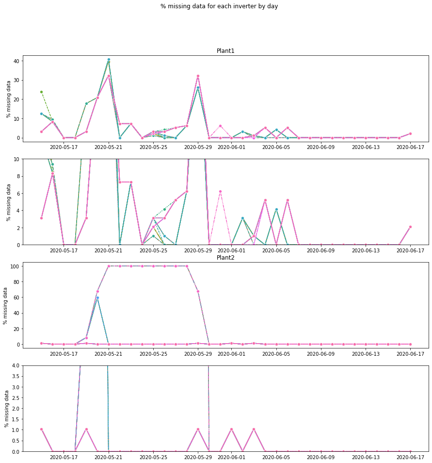

```python
r = {}
ax = {}
pos = [0,0,1,1]
n_rows = 4
n_cols = 1

r[0] = groupby_inv_date(gen_1,'24h',True)
r[1] = groupby_inv_date(gen_2,'24h',True)
r[0].index.rename('',inplace=True)
r[1].index.rename('',inplace=True)

r[0]=(1-(r[0]/96))*100
r[1]=(1-(r[1]/96))*100

fig,axes = plt.subplots(n_rows,n_cols,figsize=(15,15))
fig.suptitle('% missing data for each inverter by day')

for x,a in enumerate(range(0,n_rows*n_cols)):
    x=x%2
    ax[a] =sns.lineplot(ax=axes[a],data=r[pos[a]],legend=False,marker='o')
    ax[a].set_ylabel('% missing data')

    if x ==False:
        #ax[a].tick_params(axis='x',labelbottom=False,bottom=False)
        ax[a].set_title('Plant{}'.format(pos[a]+1))

ax[3].set_ylim(0,4)
ax[3].margins(x=0.05,y=-0.25)
ax[1].set_ylim(0,10)

plt.show()
```

**The above graphs each plot all 22 inveters**

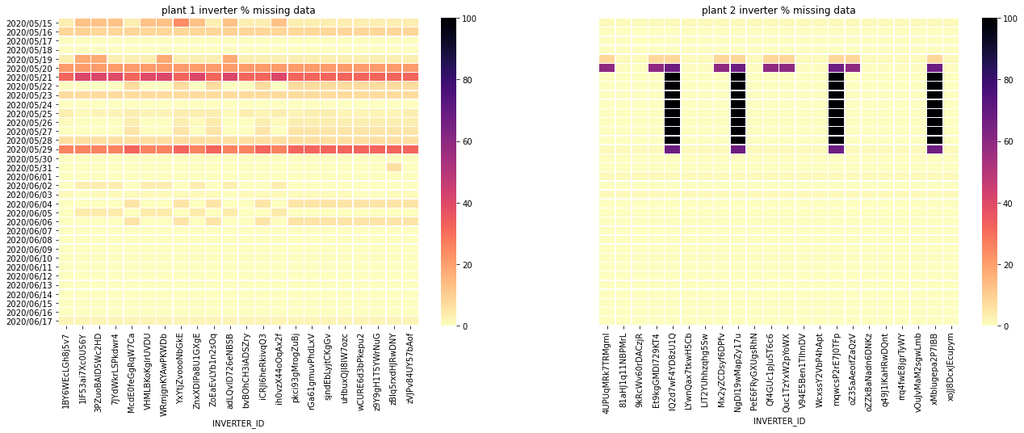

```python
h = groupby_inv_date(gen_1,'1d',True)
h2 =groupby_inv_date(gen_2,'1d',True)

fig, axes = plt.subplots(1,2,figsize=(22,7))
ax = sns.heatmap(r[0],ax=axes[0],cbar=True,linewidth=0.5,vmax=100,cmap='magma_r')
ax2 = sns.heatmap(r[1],ax=axes[1],yticklabels=False,linewidth=0.5,cmap='magma_r')

ax.set_title('plant 1 inverter % missing data')
ax2.set_title('plant 2 inverter % missing data')

ax.set_yticklabels(pd.date_range(start_date,end_date,freq='d').strftime('%Y/%m/%d'))

plt.show()
```

Using a heat map the difference in missing data between plant 1 and plant 2 is more comparable.

After looking at both the line graphs and the heat map, It could be possible especially for plant 2 that the missing data could be due to maintenance, as opposed to error or hardware malfunction. For plant_1 I am more uncertain due to the low-level spread of missing data. Despite this, there are still patterns of missing data where large quantities of inverters are missing substantial amounts of data.

# Power Output

## AC/DC power

```python
gen_1[['AC_POWER','DC_POWER']].describe()
```

|  | AC_POWER | DC_POWER |
| --- | --- | --- |
| count | 68778.000000 | 68778.000000 |
| mean | 307.802752 | 3147.426211 |
| std | 394.396439 | 4036.457169 |
| min | 0.000000 | 0.000000 |
| 25% | 0.000000 | 0.000000 |
| 50% | 41.493750 | 429.000000 |
| 75% | 623.618750 | 6366.964286 |
| max | 1410.950000 | 14471.125000 |

```python
gen_2[['AC_POWER','DC_POWER']].describe()
```

|  | AC_POWER | DC_POWER |
| --- | --- | --- |
| count | 67698.000000 | 67698.000000 |
| mean | 241.277825 | 246.701961 |
| std | 362.112118 | 370.569597 |
| min | 0.000000 | 0.000000 |
| 25% | 0.000000 | 0.000000 |
| 50% | 0.000000 | 0.000000 |
| 75% | 438.215000 | 446.591667 |
| max | 1385.420000 | 1420.933333 |

```python
gen_1['DC_POWER'] = gen_1['DC_POWER']/10
```

### Maximum/Minimum power generated in 24 hours

```python
c = ['AC_POWER','DC_POWER']
pwr1,pwr2 = groupby_power(gen_1,freq='1d',cols=c,agg_m='sum',multi_index=False,df2=gen_2,reset_i=False)
m1 = pwr1
m2 = pwr2

pwr1 = pwr1.agg(['max','min'])
pwr2 = pwr2.agg(['max','min'])
pwr = pwr1.append(pwr2)
```

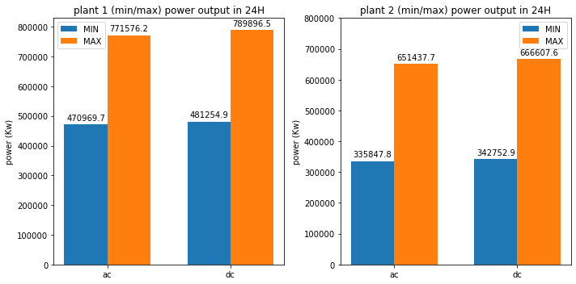

```
plant_1 ac/dc = 1.3 * Daily output of plant 2 on average.
```

```python
labels = ['ac', 'dc']

title = 'plant 1'
x = np.arange(len(labels))  # the label locations
width = 0.35  # the width of the bars

fig, ax = plt.subplots(1,2,figsize=(10,5))
rects1 = ax[0].bar(x - width/2, pwr1.iloc[1], width, label='MIN')
rects2 = ax[0].bar(x + width/2,  pwr1.iloc[0], width, label='MAX')

rects3 = ax[1].bar(x - width/2, pwr2.iloc[1], width, label='MIN')
rects4 = ax[1].bar(x + width/2,  pwr2.iloc[0], width, label='MAX')


# Add some text for labels, title and custom x-axis tick labels, etc.
ax[1].set_ylim(0,800000)

for i in range(0,2):
    ax[i].set_ylabel('power (Kw)')
    ax[i].set_title('plant {}'.format(i+1)+' (min/max) power output in 24H')
    ax[i].set_xticks(x)
    ax[i].set_xticklabels(labels)
    ax[i].legend()

def autolabel(rects,i=0):
    """Attach a text label above each bar in *rects*, displaying its height."""
    for rect in rects:
        height = rect.get_height()
        ax[i].annotate('{}'.format(round(height,1)),
                    xy=(rect.get_x() + rect.get_width() / 2, height),
                    xytext=(0, 3),  # 3 points vertical offset
                    textcoords="offset points",
                    ha='center', va='bottom')

autolabel(rects1)
autolabel(rects2)
autolabel(rects3,i=1)
autolabel(rects4,i=1)
fig.tight_layout()

plt.show()
autolabel(rects2)
v = round(m1.mean()/m2.mean(),1)
print('plant_1 ac/dc =',v[0],'* Daily output of plant 2 on average.')
```

- Over the 34 days, it seems that **plant 1** outperformed **plant 2**, Having both a higher min 24h power output and higher max 24h power output for both ac power and dc power.
- **Plant 1** on average produced 1.3* that of **plant 2's** power output by day.

### Power output over the course of a day.

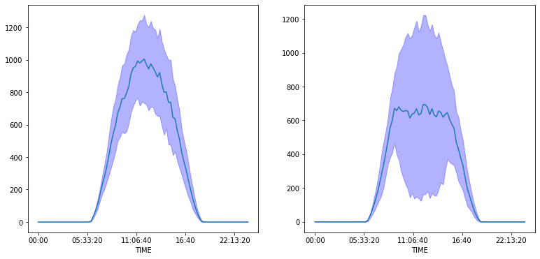

```python
g1,g2 = slice_df(['DATE_TIME','INVERTER_ID','DC_POWER'])

dc1 = split_date(g1)
dc2 = split_date(g2)
Generate_sd_mean(dc1,dc2,'DC_POWER')
plt.show()
```

- Max power output is reached at around mid day for both plant 1 and and plant 2.
- The deivation in power output is around mid day is far more significant in **PLANT 2**, this gives plot 2 the cut off apperance seen by the blue line **average**.
- **plant 2** may be having hardware issues converting power, whats interesting is that is huge deviation only seems to happend at certain period of time.
- This gives more information on why **plant 2** had a lower 24 hour max and min output compared to **plant 1**

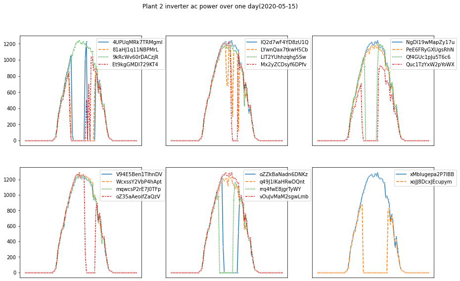

```python
x =groupby_inv_date(gen_2,freq='15T',col='AC_POWER',agg_m='mean',fillna=True)
x = x[x.index <= '2020-05-15 23:45']
x =split_date(x,h=False,reset=True)

fig,axes = plt.subplots(2,3,figsize=(15,9))
fig.suptitle('Plant 2 inverter ac power over one day(2020-05-15)')

ax0 = sns.lineplot(ax=axes[0,0],data=x.iloc[:,1:5],legend=True,marker='.')
ax1 = sns.lineplot(ax=axes[0,1],data=x.iloc[:,5:9],legend=True,marker='.')
ax2 = sns.lineplot(ax=axes[0,2],data=x.iloc[:,9:13],legend=True,marker='.')

ax3= sns.lineplot(ax=axes[1,0],data=x.iloc[:,13:17],legend=True,marker='.')
ax4= sns.lineplot(ax=axes[1,1],data=x.iloc[:,17:21],legend=True,marker='.')
ax5= sns.lineplot(ax=axes[1,2],data=x.iloc[:,21:],legend=True,marker='.')

ax_list = [ax1,ax2,ax4,ax5]
xaxis = [ax0,ax1,ax2,ax3,ax4,ax5]
for i in xaxis:
    i.tick_params(axis='x',labelbottom=False,bottom=False)
    i.legend(loc='upper right',bbox_to_anchor=(1.21,1))
for i in ax_list:
    i.tick_params(axis='y',labelleft=False,left=False)
```

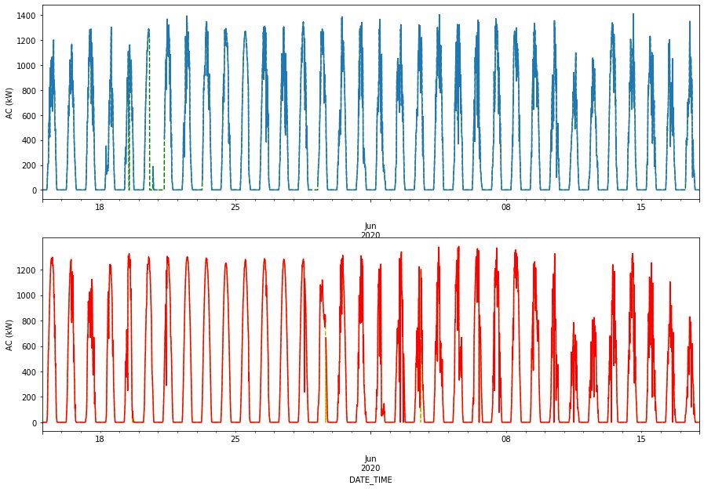

```python
g1_t15= gen_1.groupby(pd.Grouper(freq='15T',key='DATE_TIME'))
g2_t15= gen_2.groupby(pd.Grouper(freq='15T',key='DATE_TIME'))

gen1_t15_ac = g1_t15['AC_POWER'].max()
gen1_t15_dc = g1_t15['DC_POWER'].max()

gen2_t15_ac = g2_t15['AC_POWER'].max()
gen2_t15_dc = g2_t15['DC_POWER'].max()

g1_day_ac = gen1_t15_ac[(gen1_t15_ac.index >='15-05-2020 00:00')&(gen1_t15_ac.index <'2020-06-17 23:45:00')]
g1_day_ac_smoothed = g1_day_ac.fillna(0)

#g1_day_dc = gen1_t15_dc[(gen1_t15_dc.index >='15-05-2020 00:00')&(gen1_t15_dc.index <'17-05-2020 23:45')]
#g1_day_dc_smoothed = g1_day_dc.fillna(0)

g2_day_ac = gen2_t15_ac[(gen1_t15_ac.index >='15-05-2020 00:00')&(gen1_t15_ac.index <'2020-06-17 23:45:00')]
g2_day_ac_smoothed = g2_day_ac.fillna(0)

fig, axes = plt.subplots(2,1)


ax1 = g1_day_ac_smoothed.plot(ax=axes[0],figsize=(15,10),c='g',ls='--')
ax1 = g1_day_ac.plot(ax=axes[0],figsize=(15,10))

ax2 = g2_day_ac_smoothed.plot(ax=axes[1],figsize=(15,10),c='y',ls='--')
ax2 = g2_day_ac.plot(ax=axes[1],figsize=(15,10),c='r')
plt.plot()

ax2.set_yticks([0,200,400,600,800,1000,1200])

ax1.set_ylabel('AC (kW)')
ax2.set_ylabel('AC (kW)')
ax1.set_xlabel('')
plt.show()
#ax2 = g1_day_dc_smoothed.plot(ax=axes[1],figsize=(15,10),c='g',ls='--')
#ax2 = g1_day_dc.plot(ax=axes[1],figsize=(15,10))
```

## MTFB

If we assume that the missing data is because of malfunctioning hardware we can assign a score to each inverter.